# Forest Growth Model

AnnaClaire Marley

5/12/2020

### **Model of forest growth (where forest size in measured in units of carbon (C)):**

- dC/dt = 0 when air temperatures are below 0
- dC/dt = r*C for forests where carbon is below a canopy closure threshold
- dC/dt = g. for forests where carbon is above the threshold canopy closure
- dC/dt = 0 once carrying capacity is reached.

*The size of the forest (C), Canopy closure threshold and carrying capacity are all in units of carbon*

**Canopy closure threshold:** the size of the forest at which growth rates change from exponential to linear

**r**: an early exponential growth rate

**g**: the linear growth rate

#### Run the model for 300 years (using the ODE solver) starting with an initial forest size of 10 kg/C, and using the following parameters:

- canopy closure threshold (canopy_close) of 100 kgC
- a carrying capacity (k) of 500 kg C
- a early growth rate (r) of 0.01
- a later growth rate (g) of 2 kg/year
- an air temperature (temp) of 20C

```r
#### parameters ###
years = seq(from=1, to=300, by=2)
initial_forest = 10 # (kg C)
canopy_close = 100 # (kg C)
carry_capacity = 500 # (kg C)
initial_growth = 0.01 # (kg/year)
linear_growth = 2 # (kg/year)
temp = 20 # degrees C

# create parameter list
parms = list(canopy_thresh = canopy_close, K = carry_capacity,
             r = initial_growth, g = linear_growth, temp = temp)

# source model
source('../assignment_4/forest_growth.R')

# run ODE model
results = ode(y=initial_forest, times=years, func=forest_growth, parms=parms)
colnames(results)=c("year","forest_carbon")
head(results)
```

```
##      year forest_carbon
## [1,]    1      10.00000
## [2,]    3      10.20202
## [3,]    5      10.40812
## [4,]    7      10.61838
## [5,]    9      10.83288
## [6,]   11      11.05172
```

##### Graph the results

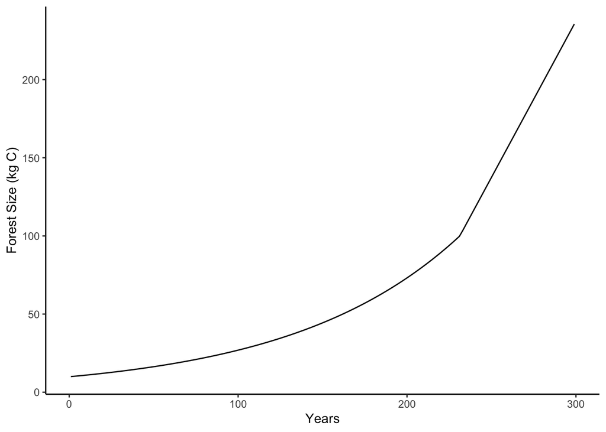

```r
ggplot(as.data.frame(results), aes(x = year, y = forest_carbon)) +
  geom_line() +
  labs(
    x = "Years",
    y = "Forest Size (kg C)"
  ) +
  theme_classic()
```

##### Run a sobol sensitivity analysis that explores how the estimated maximum forest size varies with early and later growth rates.

```r
# number of runs
np=10000

### generate two examples of random number from parmeter distributions ####

  # naming parameters
  r = rnorm(mean = 0.01, sd = 0.01/5, n=np)
  g = rnorm(mean = 2, sd = 2/5, n=np)

  # create dataframe
  X1 = cbind.data.frame(r, g)

  ## repeat process for second dataframe
  # naming parameters
  r = rnorm(mean = 0.01, sd = 0.01/5, n=np)
  g = rnorm(mean = 2, sd = 2/5, n=np)

  # create dataframe
  X2 = cbind.data.frame(r, g)

# run sobel sensitivity
sens_sobel = sobol2007(model = NULL, X1, X2, nboot = 100)
```

```r
#### run model with parameters generated from sobel ###

# Create a function to compute the maximum forest size
compute_metrics = function(result) {
  maxsize = max(result$forest_size)
  return(list(maxsize = maxsize))}

# Define a wrapper function to run solver, compute metrics, and send back results for each parameter
size_wrapper = function(time, C , r, g, func){
  parms = list(canopy_thresh = 100, K = 500,
             r = r, g = g, temp = 20)
  result = ode(y = C, times = time, func = func, parms = parms)
  colnames(result)=c("year","forest_size")
  metrics=compute_metrics(as.data.frame(result))

  return(metrics)
}

# apply functions
allresults = mapply(FUN=size_wrapper, r=sens_sobel$X$r, g=sens_sobel$X$g,
                    MoreArgs=list(C = initial_forest, time = years, func=forest_growth))
```

```
## DLSODA-  At current T (=R1), MXSTEP (=I1) steps
##       taken on this call before reaching TOUT
## In above message, I1 = 5000
##
## In above message, R1 = 291.153
##
```

```r
allres = as.data.frame(matrix(unlist(allresults), ncol=1, byrow=T))
colnames(allres) = c("maxsize")
```

##### Graph the results of the sensitivity analysis as a box plot

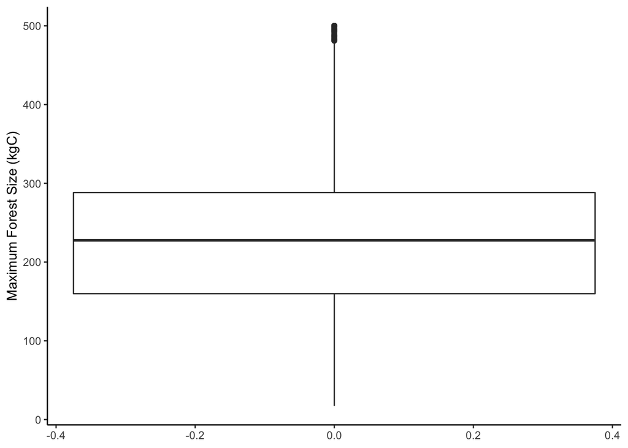

```r
# create boxplots
ggplot(allres, aes(y = maxsize))+
  geom_boxplot()+
  theme_classic()+
  ylab("Maximum Forest Size (kgC)")
```

##### Plot of the two sobol indices (S and T)

```r
# Tell sobel model the result
sens_size_maxsize = sensitivity::tell(sens_sobel, allres$maxsize)

# First-order indices
sens_size_maxsize$S
```

```
##     original        bias std. error  min. c.i. max. c.i.
## r 0.83977634 0.001057663 0.03771033 0.76514368 0.9215328
## g 0.08210473 0.001064173 0.01319169 0.04956997 0.1035390
```

```r
# Total sensitivity index
sens_size_maxsize$T
```

```
##    original         bias std. error  min. c.i. max. c.i.
## r 0.9636059  0.002574357 0.03646971 0.88499016 1.0368789
## g 0.1175286 -0.001708550 0.01474211 0.09304739 0.1557983
```

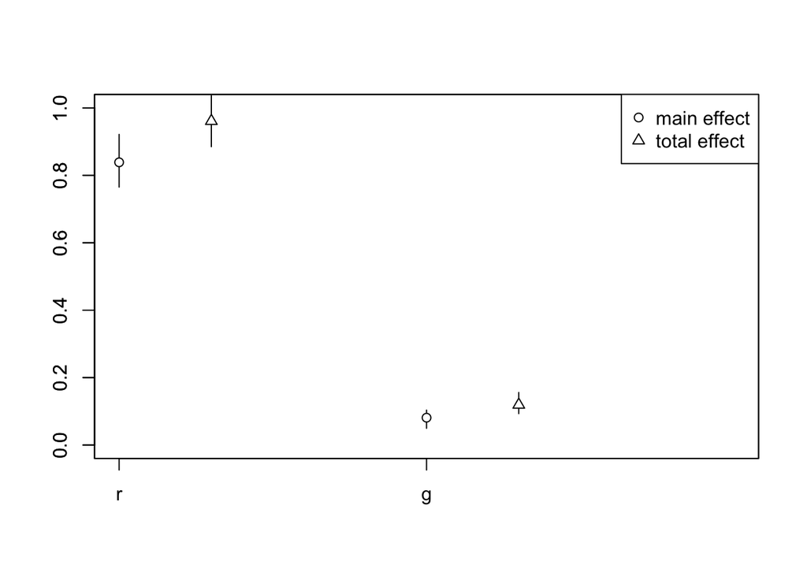

```r
plot(sens_size_maxsize)
```